# Urban Flood Risk Prediction for Melbourne

## A Spatiotemporal Machine Learning Project

**Authored by:** Hariprasath (225645766)

**Pre-requisite skills:** Python, Pandas

**Chameleon - Melbourne Open Playground (MOP)**

# Introduction

### The problem in plain terms

When heavy rain hits a city, some streets, intersections and laneways flood while others stay dry. The reason isn't just *how much* it rains — it's also about what's underneath: how big the drains are, how many stormwater pits are nearby, whether the roads are sealed or grassy, how low-lying the area is, and how many trees are around to soak up water. Climate change is making heavy rainfall events more frequent, and many cities (Melbourne included) have ageing drainage systems that weren't designed for today's storms.

### What this project does

This project builds a **flood risk prediction system** for Melbourne's central business district (CBD). It combines two very different types of data:

1. **Where things are (spatial data)** — the locations of drains, pipes, buildings, roads and trees across Melbourne.
2. **What's happening over time (temporal data)** — daily rainfall measurements from the Bureau of Meteorology going back to 2016.

We use machine learning to find patterns linking the two: which combinations of *recent rainfall* and *local infrastructure* tend to produce flood-prone conditions. The end result is a map of Melbourne where each 1km square is colour-coded by its predicted flood risk for today (or any chosen day), and an interactive web dashboard that non-technical users can open in a browser.

### Who this is for

City planners, emergency services and council teams who want to know *which neighbourhoods are most vulnerable* before a storm arrives — so they can position resources, send early warnings, and prioritise drainage upgrades in the right places.

### A note on honesty

Real flood-incident records (SES callouts, insurance claims) aren't publicly available at fine-grained spatial detail, so this project uses a **proxy label** — a rule that flags a cell as "flooded" when heavy rain meets vulnerable infrastructure. This is explained openly in Section 7. The pipeline is real and reusable; the predictions become operationally meaningful once real flood records are plugged in.

# Datasets Used

The project pulls together six open datasets. The first five come from the City of Melbourne's open data portal and describe the physical features of the city. The sixth comes from the Bureau of Meteorology (BoM) and gives us daily rainfall measurements from the Olympic Park weather station.

- Dataset 1 — Stormwater pits: https://data.melbourne.vic.gov.au/explore/dataset/stormwater-pits/information/
- Dataset 2 — Drain pipes: https://data.melbourne.vic.gov.au/explore/dataset/drainpipes/information/
- Dataset 3 — 2023 Building footprints: https://data.melbourne.vic.gov.au/explore/dataset/2023-building-footprints/information/
- Dataset 4 — Road segments with surface type: https://data.melbourne.vic.gov.au/explore/dataset/road-segments-with-surface-type/information/
- Dataset 5 — Tree canopies (2021 urban forest): https://data.melbourne.vic.gov.au/explore/dataset/tree-canopies-2021-urban-forest/information/
- Dataset 6 — Daily rainfall, Melbourne Olympic Park (BoM): https://www.bom.gov.au/jsp/ncc/cdio/weatherData/av?p_nccObsCode=136&p_display_type=dailyDataFile&p_startYear=&p_c=&p_stn_num=086338

# Workflow

The project is organised into the following sections. Each one builds on the previous:

1. **General setup & data preparation** — install libraries, define a helper to download datasets.
2. **Data preprocessing** — clean and tidy the spatial and rainfall data.
3. **Spatial feature engineering** — split Melbourne into a grid of 1km squares and compute features for each square.
4. **First modelling pass (K-Means clustering)** — group squares into Low / Medium / High risk based purely on their physical features.
5. **Spatiotemporal feature construction** *(Section 6)* — combine static spatial features with daily rainfall and rolling-window rainfall features.
6. **Proxy flood-event labels** *(Section 7)* — create training labels from a rainfall × vulnerability rule, since real flood records aren't available.
7. **Deep learning model — ConvLSTM** *(Section 8)* — train a deep learning model that learns from both space and time, and compare it to a simple baseline.
8. **Discussion, limitations & next steps** *(Section 9)*.
9. **Daily real-time prediction pipeline** *(Section 10)* — fetch fresh rainfall data and produce today's flood risk map.
10. **HTML dashboard** *(Section 11)* — a self-contained interactive dashboard for non-technical users.

> **Heads up on the section numbers:** Section 5 doesn't exist as a separate header — the original workflow merged what would have been Section 5 ("Visualisation") into Section 4. The substantive work flows on as Sections 6, 7, 8 etc. below.

## Section 1: General setting & Data preparation

Before any analysis can happen, we need to install the right Python libraries and pull down each of the six datasets. The next two code cells do exactly that — first installing `contextily` (which lets us put a map background behind our plots), then importing every library we'll use across the whole project.

```python
# ! pip install geopandas
! pip install contextily
# ! pip install requests
```

```
Downloading contextily-1.7.0-py3-none-any.whl (16 kB)
Downloading mercantile-1.2.1-py3-none-any.whl (14 kB)
```

```python
# import libraries
import warnings
warnings.filterwarnings('ignore')
import numpy as np
import pandas as pd
import geopandas as gpd
import requests
from io import StringIO
import matplotlib.pyplot as plt
import contextily as ctx
from shapely.geometry import box
from math import nan
from sklearn.preprocessing import StandardScaler
from sklearn.cluster import KMeans
from sklearn.metrics import silhouette_score, davies_bouldin_score

# optional if needed
# ! pip install geopandas
# ! pip install contextily
# ! pip install requests
```

### Collecting the data

The City of Melbourne publishes its open datasets through a standard API. Rather than downloading each one by hand, we define a small helper function called `collect_data` that takes a dataset name, fetches it over the internet, and loads it into a Python dataframe.

The rainfall dataset comes from a different source (BoM, hosted on Google Drive), so it's loaded separately right after.

```python
# Datasets from CoM
# define function to colect data
def collect_data(dataset_id, limit=-1, format="csv"):
  base_url = 'https://data.melbourne.vic.gov.au/api/explore/v2.1/catalog/datasets/'
  url = f'{base_url}{dataset_id}/exports/{format}'
  params = {
      'limit': limit,
      'lang': 'en',
      'timezone': 'UTC'
  }

  try:
    response = requests.get(url, params=params)
    response.raise_for_status()

    data = StringIO(response.text)
    if format == 'geojson':
      df = gpd.read_file(data)
    else:
      df = pd.read_csv(data, delimiter=';')
    print(f'Successfully loaded {dataset_id}, {df.shape[0]} rows and {df.shape[1]} columns, {format} format.')

    return df

  except requests.exceptions.RequestException as e:
    print(f'Error loading {dataset_id}: {e}.')
    return None

# collect datasets
pits_raw = collect_data('stormwater-pits', format='geojson')
pipes_raw = collect_data('drainpipes', format='geojson')
buildings_raw = collect_data('2023-building-footprints', format='geojson')
roads_raw = collect_data('road-segments-with-surface-type', format='geojson')
trees_raw = collect_data('tree-canopies-2021-urban-forest', format='geojson')

# Rainfall data from BoM
# dataset 6 is stored at https://drive.google.com/file/d/1lRTEPZHGKj2PKISCgEsFsVxqzLkyw-5F/view?usp=sharing
rainfall_id = '1lRTEPZHGKj2PKISCgEsFsVxqzLkyw-5F'
try:
  rainfall_raw  = pd.read_csv(f'https://drive.google.com/uc?id={rainfall_id}')
  print(f'Successfully loaded rainfall data, {rainfall_raw.shape[0]} rows and {rainfall_raw.shape[1]} columns.')
except Exception as e:
  print(f'Error loading rainfall data: {e}.')
```

```
Successfully loaded stormwater-pits, 21113 rows and 13 columns, geojson format.
Successfully loaded drainpipes, 17242 rows and 17 columns, geojson format.
Successfully loaded 2023-building-footprints, 41701 rows and 13 columns, geojson format.
Successfully loaded road-segments-with-surface-type, 56519 rows and 10 columns, geojson format.
Successfully loaded tree-canopies-2021-urban-forest, 57980 rows and 2 columns, geojson format.
Successfully loaded rainfall data, 4843 rows and 8 columns.
```

## Section 2: Data preprocessing

Raw open data is messy. Columns have inconsistent names, some rows have missing values, some entries are duplicates, and some categories (like road surface "Other" or "Not known") aren't useful for analysis. This section walks through cleaning each dataset so it's ready to be combined later.

### 2.1 Spatial data preprocessing

#### 2.1.1 Exploring raw datasets

Before cleaning anything, it's worth eyeballing each dataset to see what's there: how many rows, which columns, how many missing values. The cells below print the first 3 rows and the null-value count for each of the five spatial datasets.

Stormwater Pits dataset

```python
print(f'Pits data:\n{'='*20}\n{pits_raw.head(3)}\n\n')
print(f'Pits null values:\n{'='*20}\n{pits_raw.isnull().sum()}')
```

```
Pits data:
====================
   asset_number            asset_description construction_material_lupvalue  \
0       1596911     SWD Pit - Grated Manhole                          Brick
1       1759114          SWD Pit - Lane Type               In Situ Concrete
2       1146782  SWD Pit - Grated Side Entry                          Brick

   grate_length grate_material_lupvalue  grate_width  \
0           NaN               Cast Iron          NaN
1         450.0              Mild Steel        450.0
2         900.0              Mild Steel        430.0

                                model_descr_lupvalue model_no_lupvalue  \
0                           SWD Pit - Grated Manhole        300413-001
1              SWD Pit - Laneway Type - Unclassified        300407-000
2  SWD Pit - Grated Side Entry Pit - Non Standard...        300402-003

  object_type_lupvalue overflow_kerb_lupvalue        lat         lon  \
0       Grated Manhole                   None -37.792906  144.956536
1            Lane Type                   None -37.813643  144.967603
2    Grated Side Entry                   None -37.793758  144.955482

                      geometry
0  POINT (144.95654 -37.79291)
1   POINT (144.9676 -37.81364)
2  POINT (144.95548 -37.79376)


Pits null values:
====================
asset_number                          0
asset_description                     0
construction_material_lupvalue      139
grate_length                      11668
grate_material_lupvalue           10526
grate_width                       11673
model_descr_lupvalue                422
model_no_lupvalue                  1409
object_type_lupvalue                 47
overflow_kerb_lupvalue             1403
lat                                   0
lon                                   0
geometry                              0
dtype: int64
```

Drainpipes dataset

```python
print(f'Pipes data:\n{'='*20}\n{pipes_raw.head(3)}\n\n')
print(f'Pipes null values:\n{'='*20}\n{pipes_raw.isnull().sum()}')
```

```
Pipes data:
====================
                                        geo_point_2d built  dnstr_pit  \
0  {'lon': 144.9723773392074, 'lat': -37.83235998...   NaT  1472763.0
1  {'lon': 144.9741777544205, 'lat': -37.83075901...   NaT  1472766.0
2  {'lon': 144.97380384007778, 'lat': -37.8310363...   NaT  1472768.0

  upstr_inv  upstr_pit        ref  width_mm  condition    carrying  \
0      None  1472761.0  1473265.0       NaN        3.0  Stormwater
1      None  1472784.0  1473274.0       NaN        3.0  Stormwater
2      None  1472810.0  1473277.0       NaN        3.0  Stormwater

            operator  diameter material  height_mm  form mat_desc dnstr_inv  \
0  City of Melbourne     150.0  Unknown        NaN  Pipe     None      None
1  City of Melbourne     150.0  Plastic        NaN  Pipe     None      None
2  City of Melbourne     150.0  Plastic        NaN  Pipe     None      None

                                            geometry
0  LINESTRING (144.97236 -37.83236, 144.97239 -37...
1  LINESTRING (144.97423 -37.83064, 144.97413 -37...
2  LINESTRING (144.9738 -37.83103, 144.97381 -37....


Pipes null values:
====================
geo_point_2d        0
built            1608
dnstr_pit        2937
upstr_inv       16230
upstr_pit        3018
ref                85
width_mm         1106
condition        1430
carrying            0
operator           87
diameter          163
material            0
height_mm        1106
form                0
mat_desc         4222
dnstr_inv       16322
geometry            0
dtype: int64
```

2023 Building Footprints dataset

```python
print(f'Buildings data:\n{'='*20}\n{buildings_raw.head(3)}\n\n')
print(f'Buildings null values:\n{'='*20}\n{buildings_raw.isnull().sum()}')
```

```
Buildings data:
====================
                                        geo_point_2d objectid structure_id  \
0  {'lon': 144.95673941735046, 'lat': -37.8000353...    20012       815949
1  {'lon': 144.9077552355766, 'lat': -37.84308942...    20027       804149
2  {'lon': 144.97921111, 'lat': -37.832043207400005}    20048       815174

  footprint_type roof_type  footprint_max_elevation  footprint_min_elevation  \
0      Structure      Flat                     97.5                     91.5
1      Structure      Flat                      7.5                      3.0
2      Structure      Flat                     18.5                     16.5

   structure_max_elevation  structure_min_elevation  footprint_extrusion  \
0                    101.0                     27.5                  6.0
1                      7.5                      3.0                  4.5
2                     18.5                     16.5                  2.0

   structure_extrusion date_captured  \
0                 70.0      20180528
1                  4.5      20180528
2                  2.0      20180528

                                            geometry
0  POLYGON ((144.95672 -37.80007, 144.9568 -37.80...
1  POLYGON ((144.9078 -37.84314, 144.90777 -37.84...
2  POLYGON ((144.97925 -37.83205, 144.97919 -37.8...


Buildings null values:
====================
geo_point_2d               0
objectid                   0
structure_id               0
footprint_type             0
roof_type                  0
footprint_max_elevation    0
footprint_min_elevation    0
structure_max_elevation    0
structure_min_elevation    0
footprint_extrusion        0
structure_extrusion        0
date_captured              0
geometry                   0
dtype: int64
```

Road segments, with surface type dataset

```python
print(f'Roads data:\n{'='*20}\n{roads_raw.head(3)}\n\n')
print(f'Roads null values:\n{'='*20}\n{roads_raw.isnull().sum()}')
```

```
Roads data:
====================
                                        geo_point_2d  assetno condition  \
0  {'lon': 144.94368406627316, 'lat': -37.8194477...  1434230     3.937
1  {'lon': 144.9750594901909, 'lat': -37.79600916...  1419861      None
2  {'lon': 144.9476316634999, 'lat': -37.80911547...  1445696         4

            material  length instaldate         type  area_sqm width  \
0           Concrete     NaN 2012-09-13      Footway   243.436  None
1  Bluestone Pitcher     NaN 1990-01-01  Carriageway     3.691  None
2    Granitic Gravel     NaN        NaT       Median    10.493  None

                                            geometry
0  MULTIPOLYGON (((144.94382 -37.81969, 144.94379...
1  MULTIPOLYGON (((144.97508 -37.79601, 144.97508...
2  MULTIPOLYGON (((144.94763 -37.8091, 144.94765 ...


Roads null values:
====================
geo_point_2d        0
assetno             0
condition        2842
material           18
length          27251
instaldate       3281
type                0
area_sqm            0
width           26219
geometry            0
dtype: int64
```

Tree Canopies 2021 dataset

```python
print(f'Trees data:\n{'='*20}\n{trees_raw.head(3)}\n\n')
print(f'Trees null values:\n{'='*20}\n{trees_raw.isnull().sum()}')
```

```
Trees data:
====================
                                        geo_point_2d  \
0  {'lon': 144.9578491713787, 'lat': -37.79540177...
1  {'lon': 144.9514339834316, 'lat': -37.79535552...
2  {'lon': 144.97057737168868, 'lat': -37.7956921...

                                            geometry
0  MULTIPOLYGON (((144.95785 -37.79534, 144.95786...
1  MULTIPOLYGON (((144.95143 -37.79535, 144.95144...
2  MULTIPOLYGON (((144.97056 -37.79569, 144.97058...


Trees null values:
====================
geo_point_2d    0
geometry        0
dtype: int64
```

#### 2.1.2 Visualising raw datasets

Numbers in a table only tell you so much. The next cell plots each of the five spatial datasets on a Melbourne street map — drains as blue lines, trees as green dots, buildings as red shapes, and so on. This visual sanity check confirms the data is correctly geo-referenced and gives a feel for what we're working with.

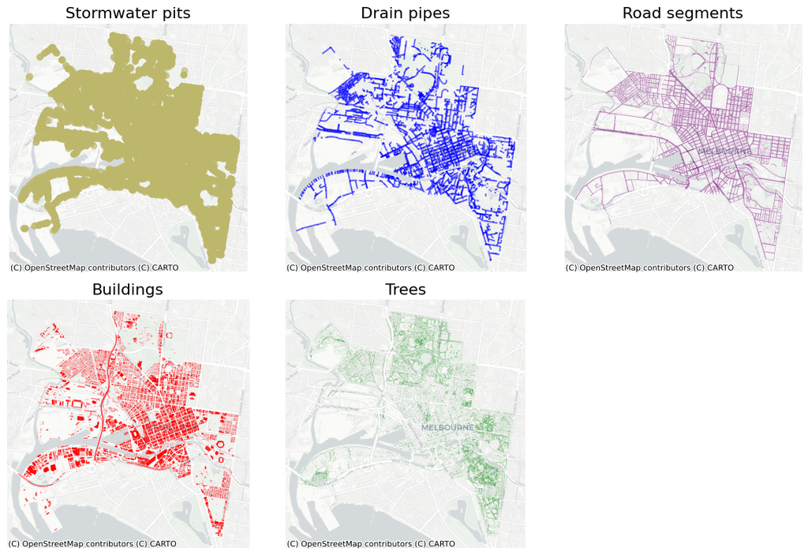

```python
# visualize data
datasets = {
    'Stormwater pits': {'df': pits_raw, 'color': 'darkkhaki'},
    'Drain pipes': {'df': pipes_raw, 'color': 'blue'},
    'Road segments': {'df': roads_raw, 'color': 'purple'},
    'Buildings': {'df': buildings_raw, 'color': 'red'},
    'Trees': {'df': trees_raw, 'color': 'green'}
}

fig, axes = plt.subplots(2, 3, figsize=(12, 8))
axes = axes.flatten()
for i, (name, info) in enumerate(datasets.items()):
  ax = axes[i]
  df = info['df'].to_crs(epsg=3857)
  color = info['color']
  df.plot(ax=ax, color=color, alpha=0.6)
  ctx.add_basemap(ax=ax, source=ctx.providers.CartoDB.Positron)
  ax.axis('off')
  ax.set_title(name, fontsize=16)
axes[5].set_visible(False)
plt.tight_layout()
plt.show()
```

#### 2.1.3 Cleaning and scoring the spatial data

Now we trim each dataset down to just the columns we need and clean it up:

- **Pits and trees** — keep only the location.
- **Pipes** — keep location and pipe diameter (bigger pipes drain more water).
- **Buildings** — keep location and the minimum elevation of each building footprint (low-lying buildings are more flood-prone).
- **Roads** — keep location and the road's surface material, then drop "Other" and "Not known".

For roads we also add a **perviousness score** — a number between 0.1 and 0.9 that describes how easily water can soak through the surface. Concrete, asphalt and bluestone are basically waterproof (score 0.1). Gravel, pavers and timber let some water through (score 0.5). Grass, turf and bare earth absorb a lot (score 0.9). More pervious surfaces = less surface runoff = less flooding.

```python
# select nescessary columns
pits = pits_raw['geometry'].drop_duplicates()
pipes = pipes_raw.dropna(subset=['diameter'])[['geometry', 'diameter']].drop_duplicates()
buildings = buildings_raw[['geometry', 'footprint_min_elevation']].drop_duplicates()
roads = roads_raw.dropna(subset=['material'])[['geometry', 'material']].drop_duplicates()
trees = trees_raw['geometry'].drop_duplicates()

# check materials
print(f'Roads material values: \n{roads['material'].unique()}')
# eliminate "other" and "not known" values
roads = roads[(roads['material'].str.lower() != "other") & (roads['material'].str.lower() != "not known")]

# score pervious values
def score_pervious(material):
    m = material.strip().lower()
    # impervious
    if any(keyword in m for keyword in [
        'concrete', 'hma', 'asphalt', 'bluestone', 'granite', 'brick',
        'steel', 'plastic', 'terrazzo', 'precast', 'pre cast',
        'cast in situ', 'cast-in-situ', 'masonry', 'iron'
    ]):
        return 0.1
    # semi-pervious
    elif any(keyword in m for keyword in [
        'crushed rock', 'gravel', 'granitec', 'granitic', 'pebble',
        'paver', 'mixture', 'timber', 'wood', 'crazy paving'
    ]):
        return 0.5
    # pervious
    elif any(keyword in m for keyword in [
        'grass', 'turf', 'plants', 'mulch', 'sand', 'unmade'
    ]):
        return 0.9
    return None

roads['pervious_score'] = roads['material'].apply(score_pervious)
print(f'\nRoads dataset with pervious score:\n{roads}')
```

```
Roads material values:
['Concrete' 'Bluestone Pitcher' 'Granitic Gravel'
 'Bluestone Paver (1000x500x40)' 'Dressed Bluestone'
 'Pre Cast Exposed Agg' 'Cast in Situ Off Form' 'HMA' 'HMA Footpath (CBD)'
 '3 Row Bluestone Pitcher' 'HMA Footpath (Non CBD)'
 '1 Row Bluestone Pitcher' '5 Row Bluestone Pitcher'
 '4 Row Bluestone Pitcher' 'Cast in Situ Exposed Agg'
 '2 Row Bluestone Pitcher' 'Concrete Paver' 'Pre Cast Off Form'
 'Granite Paver' 'Steel' 'Crushed Rock' 'Terrazzo Paver' 'Turf'
 '6 Row Bluestone Pitcher' '15 Row Bluestone Pitcher' 'Timber'
 'HMA-Porous' 'Bluestone Paver (Other)' 'Pebble Paving' 'Other Paver'
 'Other' 'Brick' 'Brick Paver' 'Sawn Bluestone Block (100x100x100)'
 'Plants' 'Masonry' 'Mulch' 'Crazy Paving' 'Unmade' 'Synthetic Turf'
 'Precast Concrete' 'Cast-In-Situ Concrete' 'Bluestone Triangle Paver'
 '9 Row Bluestone Pitcher' 'Woodpaving' '8 Row Bluestone Pitcher'
 '7 Row Bluestone Pitcher' 'Mixture of Materials' 'Wrought Iron'
 'Not Known' 'Plastic/Composite' 'Sand' 'Grass']

Roads dataset with pervious score:
                                                geometry  \
0      MULTIPOLYGON (((144.94382 -37.81969, 144.94379...
1      MULTIPOLYGON (((144.97508 -37.79601, 144.97508...
2      MULTIPOLYGON (((144.94763 -37.8091, 144.94765 ...
3      MULTIPOLYGON (((144.96702 -37.81393, 144.96712...
4      MULTIPOLYGON (((144.94342 -37.82124, 144.94412...
...                                                  ...
56514  MULTIPOLYGON (((144.92731 -37.79659, 144.92731...
56515  MULTIPOLYGON (((144.96872 -37.81481, 144.96879...
56516  MULTIPOLYGON (((144.94456 -37.803, 144.94455 -...
56517  MULTIPOLYGON (((144.94977 -37.80482, 144.94978...
56518  MULTIPOLYGON (((144.97285 -37.81247, 144.97285...

                            material  pervious_score
0                           Concrete             0.1
1                  Bluestone Pitcher             0.1
2                    Granitic Gravel             0.5
3      Bluestone Paver (1000x500x40)             0.1
4                  Dressed Bluestone             0.1
...                              ...             ...
56514          Cast in Situ Off Form             0.1
56515              Dressed Bluestone             0.1
56516              Dressed Bluestone             0.1
56517                            HMA             0.1
56518             HMA Footpath (CBD)             0.1

[56361 rows x 3 columns]
```

### 2.2 Temporal data preprocessing

#### 2.2.1 Exploring & cleaning the rainfall dataset

1. Keeps only the columns we need (year, month, day, daily rainfall in mm).
2. Filters down to 2016–2025.
3. Sorts the rows by date.
4. Fills the small number of missing rainfall values with 0 (a reasonable assumption: a missing reading on a dry day is almost certainly 0 mm).

```python
# display head of datasets and check null values
print(f'Rainfall first 3 rows:\n{'='*20}\n{rainfall_raw.head(3)}\n')
print(f'Rainfall year range: {rainfall_raw['Year'].unique()}\n\n')

rainfall = rainfall_raw.copy()

# select nescessary columns
rainfall = rainfall[['Year', 'Month', 'Day', 'Rainfall amount (millimetres)']]
rainfall.columns = ['year', 'month', 'day', 'rainfall_amount']

# select 10 recent years from 2016 to 2025 and sort by time
rainfall = rainfall[(rainfall['year'] >= 2016) & (rainfall['year'] <= 2025)]
rainfall = rainfall.sort_values(['year', 'month', 'day']).reset_index(drop=True)

# check data validation
print(f'Select Rainfall data from 2016 to 2025\n{'='*20}')
print(f'Total Rainfall observations: {len(rainfall)}')
print(f'Number of rows with null values: {rainfall['rainfall_amount'].isnull().sum()}')
print(f'Number of rows with values less than 0: {rainfall[rainfall["rainfall_amount"] < 0].shape[0]}')
print(f'Duplicated values: {rainfall_raw.duplicated().sum()}\n\n')

# assess null values
print(f'Null values:\n{'='*20}\n{rainfall[rainfall.isnull().any(axis=1)]}')
# fill some missng values with 0
rainfall = rainfall.fillna(0)

# recheck data
print('\n\nPreprocessed Rainfall data')
print('='*26)
print(f'Number of rows with null values: {rainfall['rainfall_amount'].isnull().sum()}')
print(f'\nRainfall first and last 5 rows:\n{rainfall}')
```

```
Rainfall first 3 rows:
====================
  Product code  Bureau of Meteorology station number  Year  Month  Day  \
0   IDCJAC0009                                 86338  2013      1    1
1   IDCJAC0009                                 86338  2013      1    2
2   IDCJAC0009                                 86338  2013      1    3

   Rainfall amount (millimetres)  \
0                            NaN
1                            NaN
2                            NaN

   Period over which rainfall was measured (days) Quality
0                                             NaN     NaN
1                                             NaN     NaN
2                                             NaN     NaN

Rainfall year range: [2013 2014 2015 2016 2017 2018 2019 2020 2021 2022 2023 2024 2025 2026]


Select Rainfall data from 2016 to 2025
====================
Total Rainfall observations: 3653
Number of rows with null values: 4
Number of rows with values less than 0: 0
Duplicated values: 0


Null values:
====================
      year  month  day  rainfall_amount
1012  2018     10    9              NaN
1013  2018     10   10              NaN
2015  2021      7    8              NaN
2016  2021      7    9              NaN


Preprocessed Rainfall data
==========================
Number of rows with null values: 0

Rainfall first and last 5 rows:
      year  month  day  rainfall_amount
0     2016      1    1              0.0
1     2016      1    2              0.0
2     2016      1    3              0.0
3     2016      1    4              0.0
4     2016      1    5              0.0
...    ...    ...  ...              ...
3648  2025     12   27              0.0
3649  2025     12   28              0.0
3650  2025     12   29              0.0
3651  2025     12   30              0.0
3652  2025     12   31              0.0

[3653 rows x 4 columns]
```

#### 2.2.2 Visualising the rainfall data

A quick bar chart of total annual rainfall over the 10-year window. This is just a sanity check — we expect to see year-to-year variation but no shocking outliers. If one year showed 10× the usual rainfall, that would point to a data error.

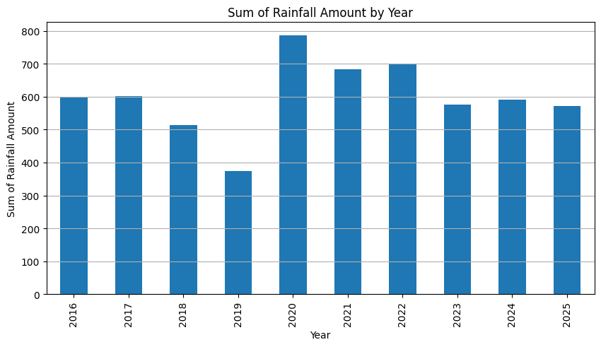

```python
plt.figure(figsize=(10,5))
rainfall.groupby('year')['rainfall_amount'].sum().plot(kind='bar')
plt.title('Sum of Rainfall Amount by Year')
plt.xlabel('Year')
plt.ylabel('Sum of Rainfall Amount')
plt.grid(axis='y')
plt.show()
```

## Section 3: Feature engineering — building a grid of Melbourne

| Feature | What it means | Why it matters for flooding |
| --- | --- | --- |
| `pit_count` | How many stormwater pits sit inside this square | More pits = more places for water to drain away |
| `tree_count` | How many trees are in this square | Trees catch rain and help water soak into the soil |
| `pipe_drainage_score` | Number of drain pipes × their average diameter | Bigger and more numerous pipes = more drainage capacity |
| `avg_min_elevation` | Average elevation of building bases in the square | Lower-lying areas collect water from surrounding higher ground |
| `road_pervious_score` | Number of roads × their average perviousness | More water-permeable roads = less surface runoff |

Together these five numbers describe how well a given square of Melbourne can cope with heavy rain. A high score on all five means an area is well-equipped to drain water; a low score on all five means an area is vulnerable.

### 3.1 Building the grid and joining features

The code below first creates the grid of empty squares, then uses spatial joins (counting which points and lines fall inside each square) to populate the five feature columns. Squares with no roads or no drain pipes are dropped — they're outside the meaningful study area.

```python
# create grids data frame for spartial variables
# xmin, ymin, xmax, ymax = buildings.to_crs("EPSG:28355").total_bounds
xmin, ymin, xmax, ymax = roads.to_crs("EPSG:28355").total_bounds
cell_size = 1000

grid_cells = []
for x in np.arange(xmin, xmax, cell_size):
  for y in np.arange(ymin, ymax, cell_size):
    grid_cells.append(box(x, y, x + cell_size, y + cell_size))
grids = gpd.GeoDataFrame(geometry = grid_cells, crs = "EPSG:28355")
grids["id"] = range(len(grids))
grids = grids[['id', 'geometry']]


## create features and merge into grids
# pits feature: total number of pits per area
pits = gpd.GeoDataFrame(pits, geometry='geometry')
pits = pits.to_crs(grids.crs)
pits_joined = gpd.sjoin(pits, grids, how="inner", predicate="intersects")
pits_features = (
    pits_joined.groupby("id").size()
    .reset_index(name="pit_count")
)
grids = grids.merge(pits_features, on='id', how='left')

# trees feature: total number of trees per area
trees = gpd.GeoDataFrame(trees, geometry='geometry')
trees = trees.to_crs(grids.crs)
trees_joined = gpd.sjoin(trees, grids, how="inner", predicate="intersects")
trees_features = (
    trees_joined.groupby("id").size()
    .reset_index(name="tree_count")
)
grids = grids.merge(trees_features, on='id', how='left')

# pipes feature: combination of total number of pipes and average diameter
pipes = pipes.to_crs(grids.crs)
pipes_joined = gpd.sjoin(pipes, grids, how="inner", predicate="intersects")
pipes_features = (
    pipes_joined.groupby("id").agg(
        pipe_count=("geometry", "count"),
        avg_pipe_diameter=("diameter", "mean")
    ).reset_index()
)
pipes_features['pipe_drainage_score'] = pipes_features['pipe_count'] * pipes_features['avg_pipe_diameter']
pipes_features.drop(columns=['pipe_count', 'avg_pipe_diameter'], inplace=True)
grids = grids.merge(pipes_features, on='id', how='left')

# buildings feature: combination of total number of buildings and average min elevator
buildings = buildings.to_crs(grids.crs)
buildings_joined = gpd.sjoin(buildings, grids, how="inner", predicate="intersects")
buildings_features = (
    buildings_joined.groupby("id").agg(
        avg_min_elevation=("footprint_min_elevation", "mean")
    ).reset_index()
)
grids = grids.merge(buildings_features, on='id', how='left')

# roads feature: combination of total number of roads and pervious capacity
roads = roads.to_crs(grids.crs)
roads_joined = gpd.sjoin(roads, grids, how="inner", predicate="intersects")
roads_features = (
    roads_joined.groupby("id").agg(
        road_count=("geometry", "count"),
        avg_pervious_score=("pervious_score", "mean")
    ).reset_index()
)
roads_features['road_pervious_score'] = roads_features['road_count'] * roads_features['avg_pervious_score']
roads_features.drop(columns=['road_count', 'avg_pervious_score'], inplace=True)
grids = grids.merge(roads_features, on='id', how='left')

# drop grid with nan values
grids = grids[~grids['road_pervious_score'].isna()].reset_index(drop=True)
grids = grids[grids['pipe_drainage_score']!=0].reset_index(drop=True)

print('Spatial data:')
print('='*50)
print(grids.head(5))
print(f'\n\nNull values:\n{grids.isnull().sum()}')
```

```
Spatial data:
==================================================
   id                                           geometry  pit_count  \
0   2  POLYGON ((316210.674 5810839.569, 316210.674 5...      141.0
1   3  POLYGON ((316210.674 5811839.569, 316210.674 5...        3.0
2   4  POLYGON ((316210.674 5812839.569, 316210.674 5...      106.0
3   5  POLYGON ((316210.674 5813839.569, 316210.674 5...       50.0
4   6  POLYGON ((316210.674 5814839.569, 316210.674 5...        2.0

   tree_count  pipe_drainage_score  avg_min_elevation  road_pervious_score
0      1139.0              73500.0           5.771429                 35.8
1        74.0               2700.0           3.153043                  0.8
2       120.0              22050.0           3.623913                 26.6
3       163.0              10275.0           3.291429                 17.0
4       525.0                300.0          10.717476                  3.5


Null values:
id                     0
geometry               0
pit_count              0
tree_count             0
pipe_drainage_score    0
avg_min_elevation      0
road_pervious_score    0
dtype: int64
```

### 3.2 Visualising the cleaned spatial data on the grid

A final visual check: plot each cleaned dataset (pits, pipes, roads, buildings, trees) overlaid with the 1km grid, so we can see how the features are distributed across the city.

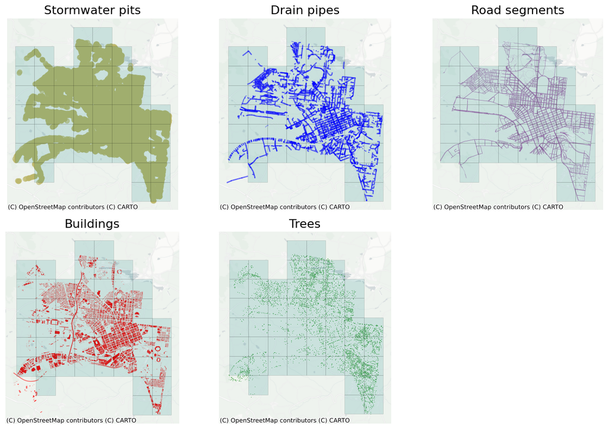

```python
datasets = {
    'Stormwater pits': {'df': pits, 'color': 'darkkhaki'},
    'Drain pipes': {'df': pipes, 'color': 'blue'},
    'Road segments': {'df': roads, 'color': 'purple'},
    'Buildings': {'df': buildings, 'color': 'red'},
    'Trees': {'df': trees, 'color': 'green'}
}

fig, axes = plt.subplots(2, 3, figsize=(12, 8))
axes = axes.flatten()
for i, (name, info) in enumerate(datasets.items()):
  ax = axes[i]
  df = info['df']
  color = info['color']
  df.plot(ax=ax, color=color, alpha=0.6)
  grids.plot(ax=ax, color='teal', alpha=0.15, edgecolor='black', linewidth=0.5)
  ctx.add_basemap(ax=ax, source=ctx.providers.CartoDB.Positron)
  ax.axis('off')
  ax.set_title(name, fontsize=16)
axes[5].set_visible(False)
plt.tight_layout()
plt.show()
```

## Section 4: First modelling pass — clustering with K-Means

The intuition: if we cluster into 3 groups, we'd expect:

- One group of squares with **lots of drainage and trees, high elevation, pervious roads** → low flood risk.
- One group with **moderate drainage and mixed surfaces** → medium risk.
- One group with **little drainage, few trees, low elevation, sealed roads** → high risk.

Importantly, **K-Means only uses the static physical features** here — it doesn't see rainfall at all. So this gives us a baseline picture of which areas of Melbourne are *structurally* vulnerable, regardless of weather.

The code below runs K-Means twice for exploration:

- **First attempt:** 5 clusters (just to see if there's more nuance than 3).
- **Second attempt:** 3 clusters — this is the one we'll use, because it maps cleanly onto Low / Medium / High risk.

For each run we print the average feature values per cluster, which is what tells us which cluster corresponds to which risk level.

```python
# K-means model

km = KMeans(n_clusters=5, random_state=42, n_init=10)

grids_labeled = grids.copy()

# Feature standardisation
X = grids_labeled.drop(columns=['id', 'geometry'])
scaler = StandardScaler()
X_scaled = scaler.fit_transform(X)

# Train model
labels = km.fit_predict(X_scaled)

# Add label to data
grids_labeled['cluster'] = labels
print(grids_labeled.head())

# Cluster summary
cluster_summary = grids_labeled.drop(columns=['id', 'geometry']).groupby('cluster').mean()
print(f'\n\nCluster average values:\n{'='*20}\n{cluster_summary}')
```

```
   id                                           geometry  pit_count  \
0   2  POLYGON ((316210.674 5810839.569, 316210.674 5...      141.0
1   3  POLYGON ((316210.674 5811839.569, 316210.674 5...        3.0
2   4  POLYGON ((316210.674 5812839.569, 316210.674 5...      106.0
3   5  POLYGON ((316210.674 5813839.569, 316210.674 5...       50.0
4   6  POLYGON ((316210.674 5814839.569, 316210.674 5...        2.0

   tree_count  pipe_drainage_score  avg_min_elevation  road_pervious_score  \
0      1139.0              73500.0           5.771429                 35.8
1        74.0               2700.0           3.153043                  0.8
2       120.0              22050.0           3.623913                 26.6
3       163.0              10275.0           3.291429                 17.0
4       525.0                300.0          10.717476                  3.5

   cluster
0        3
1        3
2        3
3        3
4        3


Cluster average values:
====================
           pit_count   tree_count  pipe_drainage_score  avg_min_elevation  \
cluster
0         632.333333  1662.666667        201827.083333          17.310555
1         869.500000  1988.250000        227187.500000          37.004830
2         236.800000  1441.300000         74247.500000          34.532260
3         117.190476   518.857143         48330.952381           9.743286
4        1722.666667  1465.333333        455300.000000          36.353600

         road_pervious_score
cluster
0                 224.025000
1                 512.625000
2                 116.530000
3                  31.033333
4                 381.333333
```

```python
# K-means model
# GNN
km = KMeans(n_clusters=3, random_state=42, n_init=10)

grids_labeled = grids.copy()

# Feature standardisation
X = grids_labeled.drop(columns=['id', 'geometry'])
scaler = StandardScaler()
X_scaled = scaler.fit_transform(X)

# Train model
labels = km.fit_predict(X_scaled)

# Add label to data
grids_labeled['cluster'] = labels
print(grids_labeled.head(3))

# Cluster summary
cluster_summary = grids_labeled.drop(columns=['id', 'geometry']).groupby('cluster').mean()
print(f'\n\nCluster average values:\n{'='*20}\n{cluster_summary}')
```

```
   id                                           geometry  pit_count  \
0   2  POLYGON ((316210.674 5810839.569, 316210.674 5...      141.0
1   3  POLYGON ((316210.674 5811839.569, 316210.674 5...        3.0
2   4  POLYGON ((316210.674 5812839.569, 316210.674 5...      106.0

   tree_count  pipe_drainage_score  avg_min_elevation  road_pervious_score  \
0      1139.0              73500.0           5.771429                 35.8
1        74.0               2700.0           3.153043                  0.8
2       120.0              22050.0           3.623913                 26.6

   cluster
0        0
1        0
2        0


Cluster average values:
====================
           pit_count   tree_count  pipe_drainage_score  avg_min_elevation  \
cluster
0         116.826087   526.478261         47633.695652          11.785660
1        1213.875000  1736.750000        322825.000000          35.399258
2         456.052632  1663.526316        146096.052632          24.235481

         road_pervious_score
cluster
0                  35.134783
1                 424.962500
2                 183.789474
```

### Interpreting the clusters

Looking at the average feature values for each cluster (printed above), we can read off the risk levels. Remember: **higher values = more protective infrastructure = lower flood risk**.

- **Cluster 1: Lowest risk** — high counts of pits, trees, pipes; higher elevation; more pervious roads.
- **Cluster 2: Moderate risk** — middling values across the board.
- **Cluster 0: Highest risk** — low drainage capacity, low elevation, mostly impervious surfaces.

The next cell relabels each square with its risk level and draws a colour-coded map of Melbourne CBD.

[figure not shown]

```python
risk_label_map = {
    1: "Low",
    2: "Medium",
    0: "High"
}

grids_labeled['risk_label'] = grids_labeled['cluster'].map(risk_label_map)
grids_labeled['risk_label'] = pd.Categorical(grids_labeled['risk_label'],
    categories=['Low', 'Medium', 'High'], ordered=True)

fig, ax = plt.subplots(figsize=(10, 10))

grids_plot = grids_labeled.to_crs(epsg=3857)
grids_plot.plot(
    ax=ax,
    column='risk_label',
    cmap='RdYlGn_r',
    alpha=0.5,
    edgecolor='black',
    linewidth=0.5,
    legend=True
)
ctx.add_basemap(ax=ax, source=ctx.providers.CartoDB.Positron)
ax.axis('off')
ax.set_title('Flood risk across Melbourne', fontsize=20)

plt.tight_layout()
plt.show()
```

### Looking at the seasonal rainfall pattern

The map above tells us *which* areas are physically vulnerable, but not *when* flooding is likely. Rainfall in Melbourne isn't spread evenly across the year, so it's useful to see which months tend to be wettest.

The next cell groups the daily rainfall data by month and averages it across all 10 years, producing a typical-year rainfall profile.

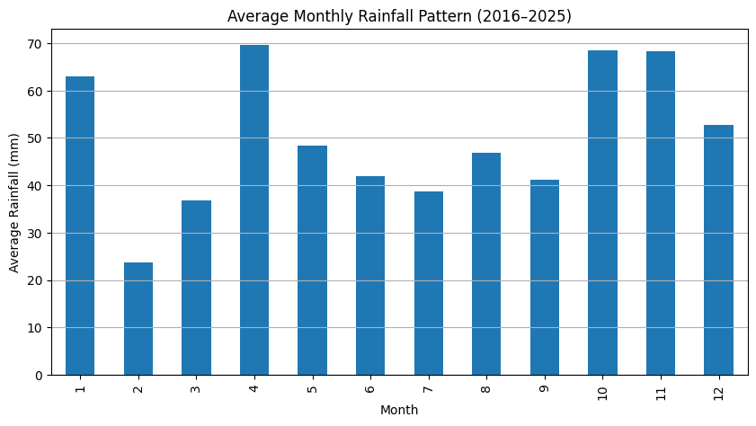

```python
rainfall_df = rainfall.copy()

monthly_rainfall = (
    rainfall_df
    .groupby(['year', 'month'])['rainfall_amount']
    .sum()
    .reset_index()
)

monthly_avg = (
    monthly_rainfall
    .groupby('month')['rainfall_amount']
    .mean()
)

plt.figure(figsize=(10,5))
monthly_avg.plot(kind='bar')
plt.xlabel('Month')
plt.ylabel('Average Rainfall (mm)')
plt.title('Average Monthly Rainfall Pattern (2016–2025)')
plt.grid(axis='y')
plt.show()
```

## Section 6: Spatiotemporal feature construction — combining space with time

Up to now we've kept the spatial side (the grid of squares) and the temporal side (daily rainfall) completely separate. The K-Means model in Section 4 only looked at static features and produced a single risk label per square that never changes — but in reality, a square's flood risk *changes day by day* as rainfall builds up.

This section combines them into a single dataset where **every grid square has its own time series**. For each (square, day) pair, we store:

- **The static features** (drainage, elevation, trees, etc.) — same across all days.
- **Today's rainfall (`rain_t`)** — how many mm fell on this day.
- **3-day cumulative rainfall (`rain_3d`)** — captures short bursts of heavy rain.
- **7-day cumulative rainfall (`rain_7d`)** — captures sustained wet spells when the ground is already saturated.
- **30-day rainfall anomaly (`rain_30d_anom`)** — how much the last month's rainfall differs from the typical amount for that calendar month. This captures unusually wet seasons.

The end result is a 3D tensor of shape `(grid_cells, days, features)` — the standard input format for spatiotemporal machine learning models.

```python
# Build the spatiotemporal feature dataframe
import datetime as dt

# --- 1. Reshape rainfall into a daily time series with a proper datetime index ---
rainfall_ts = rainfall.copy()
rainfall_ts['date'] = pd.to_datetime(rainfall_ts[['year', 'month', 'day']])
rainfall_ts = rainfall_ts[['date', 'rainfall_amount']].sort_values('date').reset_index(drop=True)

# Ensure no gaps in the daily index
full_range = pd.date_range(rainfall_ts['date'].min(), rainfall_ts['date'].max(), freq='D')
rainfall_ts = rainfall_ts.set_index('date').reindex(full_range).fillna(0.0)
rainfall_ts.index.name = 'date'
rainfall_ts.columns = ['rain_t']

# --- 2. Build lag / rolling features ---
rainfall_ts['rain_3d']  = rainfall_ts['rain_t'].rolling(window=3,  min_periods=1).sum()
rainfall_ts['rain_7d']  = rainfall_ts['rain_t'].rolling(window=7,  min_periods=1).sum()
rainfall_ts['rain_30d'] = rainfall_ts['rain_t'].rolling(window=30, min_periods=1).sum()

# 30-day anomaly: current 30-day sum minus the long-run mean 30-day sum for that calendar month
month_mean_30d = rainfall_ts.groupby(rainfall_ts.index.month)['rain_30d'].transform('mean')
rainfall_ts['rain_30d_anom'] = rainfall_ts['rain_30d'] - month_mean_30d
rainfall_ts = rainfall_ts.drop(columns=['rain_30d'])

print(f'Daily rainfall feature frame shape: {rainfall_ts.shape}')
print(rainfall_ts.head(10))
print(f'\nDate range: {rainfall_ts.index.min().date()} -> {rainfall_ts.index.max().date()}')
print(f'Total days: {len(rainfall_ts)}')
```

```
Daily rainfall feature frame shape: (3653, 4)
            rain_t  rain_3d  rain_7d  rain_30d_anom
date
2016-01-01     0.0      0.0      0.0     -47.371613
2016-01-02     0.0      0.0      0.0     -47.371613
2016-01-03     0.0      0.0      0.0     -47.371613
2016-01-04     0.0      0.0      0.0     -47.371613
2016-01-05     0.0      0.0      0.0     -47.371613
2016-01-06     0.0      0.0      0.0     -47.371613
2016-01-07     0.0      0.0      0.0     -47.371613
2016-01-08     0.0      0.0      0.0     -47.371613
2016-01-09     0.0      0.0      0.0     -47.371613
2016-01-10     0.0      0.0      0.0     -47.371613

Date range: 2016-01-01 -> 2025-12-31
Total days: 3653
```

```python
# --- 3. Broadcast: combine static spatial features with daily rainfall features ---
# Result: a long-format dataframe (grid_id, date, static_features..., rain_features...)

# Static spatial features per grid cell (drop geometry for the tensor)
static_feats = grids.drop(columns=['geometry']).copy()
# Fill any NaN spatial features with 0 (a cell with no pits has pit_count = 0, not NaN)
static_feats = static_feats.fillna(0)
static_cols = [c for c in static_feats.columns if c != 'id']
print(f'Static feature columns: {static_cols}')
print(f'Number of grid cells: {len(static_feats)}')

# Broadcast static features over time, and rainfall features over space
# Use a cross-join via merge on a dummy key — memory-friendly for our grid (~37 cells) x 3653 days
rain_long = rainfall_ts.reset_index().rename(columns={'index': 'date'})
print(f'Rainfall rows: {len(rain_long)}')

# Cross-product
static_feats['_key'] = 1
rain_long['_key'] = 1
st_df = static_feats.merge(rain_long, on='_key').drop(columns=['_key'])
static_feats = static_feats.drop(columns=['_key'])

print(f'\nSpatiotemporal long-format dataframe shape: {st_df.shape}')
print(f'Expected: {len(static_feats)} cells x {len(rain_long)} days = {len(static_feats)*len(rain_long)} rows')
print(f'\nFirst rows:')
print(st_df.head(3))
```

```
Static feature columns: ['pit_count', 'tree_count', 'pipe_drainage_score', 'avg_min_elevation', 'road_pervious_score']
Number of grid cells: 50
Rainfall rows: 3653

Spatiotemporal long-format dataframe shape: (182650, 11)
Expected: 50 cells x 3653 days = 182650 rows

First rows:
   id  pit_count  tree_count  pipe_drainage_score  avg_min_elevation  \
0   2      141.0      1139.0              73500.0           5.771429
1   2      141.0      1139.0              73500.0           5.771429
2   2      141.0      1139.0              73500.0           5.771429

   road_pervious_score       date  rain_t  rain_3d  rain_7d  rain_30d_anom
0                 35.8 2016-01-01     0.0      0.0      0.0     -47.371613
1                 35.8 2016-01-02     0.0      0.0      0.0     -47.371613
2                 35.8 2016-01-03     0.0      0.0      0.0     -47.371613
```

```python
# --- 4. Build the final tensor: (n_cells, n_days, n_features) ---
feature_cols = static_cols + ['rain_t', 'rain_3d', 'rain_7d', 'rain_30d_anom']
n_cells = st_df['id'].nunique()
n_days  = st_df['date'].nunique()
n_feats = len(feature_cols)

# Sort and reshape
st_df = st_df.sort_values(['id', 'date']).reset_index(drop=True)
X_tensor = st_df[feature_cols].values.reshape(n_cells, n_days, n_feats).astype(np.float32)

print(f'Spatiotemporal tensor shape: {X_tensor.shape}')
print(f'  axis 0 (grid cells): {X_tensor.shape[0]}')
print(f'  axis 1 (days)      : {X_tensor.shape[1]}')
print(f'  axis 2 (features)  : {X_tensor.shape[2]}  -> {feature_cols}')
print(f'\nMemory footprint: {X_tensor.nbytes/1e6:.2f} MB')

# Keep date and cell-id index arrays for later
date_index = sorted(st_df['date'].unique())
cell_index = sorted(st_df['id'].unique())
date_index = pd.to_datetime(date_index)
print(f'\nTensor covers {date_index[0].date()} -> {date_index[-1].date()}')
```

```
Spatiotemporal tensor shape: (50, 3653, 9)
  axis 0 (grid cells): 50
  axis 1 (days)      : 3653
  axis 2 (features)  : 9  -> ['pit_count', 'tree_count', 'pipe_drainage_score', 'avg_min_elevation', 'road_pervious_score', 'rain_t', 'rain_3d', 'rain_7d', 'rain_30d_anom']

Memory footprint: 6.58 MB

Tensor covers 2016-01-01 -> 2025-12-31
```

## Section 7: Creating proxy flood-event labels

### The honest problem we have to solve

Supervised machine learning needs **labelled examples** to learn from — in our case, days and locations where flooding actually happened, paired with days and locations where it didn't. The trouble is, **no public dataset gives us this**. Real flood records exist (VicSES emergency callouts, Melbourne Water records, insurance claims) but they aren't freely available at the fine spatial detail we need.

So we do the next best thing: we build a **proxy label** from a sensible rule. This isn't a substitute for real flood records — it's a principled stand-in that lets us demonstrate the full machine learning pipeline.

### The rule

We label a grid cell `i` as having a "flood-risk event" on day `t` if **both** conditions are true:

1. The cumulative rainfall over the last 3 days exceeds the 95th percentile of all 3-day rainfall totals (i.e. it's an unusually heavy 3-day downpour), **AND**
2. The cell's static vulnerability score puts it in the upper half of all cells (i.e. it has poor drainage, low elevation, mostly impervious surfaces, few trees).

In plain English: *"This is a heavy-rain day, AND this is one of the more vulnerable cells."* The intersection of those two is when flooding becomes likely.

### Why this matters to be transparent about

When the deep learning model later achieves a high accuracy score, it's not because it's predicting *real floods* — it's because it's learning to recover the rule we just wrote down. The model architecture and pipeline are completely real and reusable; only the labels are synthetic. To turn this into a real operational system, swap our proxy labels for VicSES historical callout data and retrain — no other code changes required.

```python
# Build proxy flood labels

# --- Static vulnerability score per cell ---
# Higher = more vulnerable. We invert "protective" features (more pits, trees, drainage, elevation, perviousness = less vulnerable)
sv = static_feats.copy()
# Z-score each column then sum the inverted z-scores
for col in static_cols:
    sv[col] = -(sv[col] - sv[col].mean()) / (sv[col].std() + 1e-9)
sv['vulnerability'] = sv[static_cols].sum(axis=1)
print('Vulnerability score distribution:')
print(sv['vulnerability'].describe())

vuln_threshold = sv['vulnerability'].median()  # upper half = vulnerable
vulnerable_cells = set(sv[sv['vulnerability'] > vuln_threshold]['id'].tolist())
print(f'\nNumber of vulnerable cells (upper half): {len(vulnerable_cells)} / {len(sv)}')
```

```
Vulnerability score distribution:
count    5.000000e+01
mean     2.131628e-16
std      4.148780e+00
min     -1.056446e+01
25%     -2.706601e+00
50%      2.079846e-01
75%      3.802216e+00
max      5.812402e+00
Name: vulnerability, dtype: float64

Number of vulnerable cells (upper half): 25 / 50
```

```python
# --- Rainfall trigger threshold ---
# Use 95th percentile of 3-day rainfall as the heavy-rain trigger
rain_threshold = rainfall_ts['rain_3d'].quantile(0.95)
print(f'95th percentile of 3-day rainfall (heavy-rain trigger): {rain_threshold:.2f} mm')

# --- Construct labels (n_cells, n_days) ---
# Boolean: cell vulnerable AND day's 3-day rain above threshold
cell_is_vuln = np.array([cid in vulnerable_cells for cid in cell_index]).reshape(-1, 1)
rain_3d_series = rainfall_ts['rain_3d'].loc[date_index].values.reshape(1, -1)
day_is_heavy = rain_3d_series > rain_threshold

Y = (cell_is_vuln & day_is_heavy).astype(np.int8)
print(f'\nLabel tensor shape: {Y.shape}  (n_cells, n_days)')
print(f'Positive label rate: {Y.mean()*100:.2f}%  ({Y.sum()} events out of {Y.size} cell-days)')
print(f'Days with at least one flood event: {(Y.sum(axis=0) > 0).sum()} / {Y.shape[1]}')
```

```
95th percentile of 3-day rainfall (heavy-rain trigger): 22.60 mm

Label tensor shape: (50, 3653)  (n_cells, n_days)
Positive label rate: 2.49%  (4550 events out of 182650 cell-days)
Days with at least one flood event: 182 / 3653
```

## Section 8: The main model — baseline + deep learning (ConvLSTM)

This is where the real machine learning happens. We train two models and compare them.

### Model 1: Logistic regression (the baseline)

The simplest sensible model. It looks at each (cell, day) pair independently — the cell's static features plus that day's rainfall numbers — and outputs a flood probability. It **doesn't** know about neighbouring cells, and it **doesn't** look at how the situation has been changing over time. It's the bar a more sophisticated model needs to clear: if our deep learning model doesn't beat this, the extra complexity isn't earning its keep.

### Model 2: ConvLSTM (the deep learning model)

**Conv** stands for **Convolutional** — the model treats Melbourne as a 2D image, where each "pixel" is a 1km square. Convolution lets the model learn that neighbouring squares influence each other (a flooded street upstream affects the streets downstream).

**LSTM** stands for **Long Short-Term Memory** — a type of neural network designed to learn from sequences. It looks at the last 7 days of "rainfall images" and learns how flood risk *builds up* over time as the ground saturates.

Put together, **ConvLSTM looks at the last week of Melbourne as a series of images and predicts tomorrow's flood-risk map.** It's the standard architecture for this kind of spatiotemporal forecasting problem (introduced by Shi et al. in 2015 for precipitation nowcasting).

### How we measure success — fairly

```python
# Install pytorch if needed
# !pip install torch --quiet
import torch
import torch.nn as nn
from torch.utils.data import DataLoader, TensorDataset
from sklearn.linear_model import LogisticRegression
from sklearn.metrics import roc_auc_score, average_precision_score, classification_report

device = torch.device('cuda' if torch.cuda.is_available() else 'cpu')
print(f'Using device: {device}')
print(f'PyTorch version: {torch.__version__}')
```

```
Using device: cpu
PyTorch version: 2.10.0+cpu
```

```python
# --- Map cells onto a 2D grid (row, col) for ConvLSTM ---
# Recover the (row, col) position of each cell from its geometry centroid

centroids = grids.copy()
centroids['cx'] = centroids.geometry.centroid.x
centroids['cy'] = centroids.geometry.centroid.y

# Unique x and y coords correspond to columns and rows
xs = sorted(centroids['cx'].unique())
ys = sorted(centroids['cy'].unique(), reverse=True)  # north at the top
col_of = {x: i for i, x in enumerate(xs)}
row_of = {y: i for i, y in enumerate(ys)}

centroids['col'] = centroids['cx'].map(col_of)
centroids['row'] = centroids['cy'].map(row_of)

n_rows = centroids['row'].max() + 1
n_cols = centroids['col'].max() + 1
print(f'Spatial grid dimensions: {n_rows} rows x {n_cols} cols = {n_rows*n_cols} cells')
print(f'Cells with data: {len(centroids)}')

# Build a (n_rows, n_cols) index map: -1 if no cell at that position
grid_index_map = -np.ones((n_rows, n_cols), dtype=np.int64)
for _, r in centroids.iterrows():
    cell_pos_in_tensor = cell_index.index(r['id'])
    grid_index_map[int(r['row']), int(r['col'])] = cell_pos_in_tensor

# Mask of valid cells
valid_mask = (grid_index_map >= 0)
print(f'Valid-cell mask sum: {valid_mask.sum()}')
```

```
Spatial grid dimensions: 9 rows x 8 cols = 72 cells
Cells with data: 50
Valid-cell mask sum: 50
```

```python
# --- Reshape tensor into (n_days, n_features, n_rows, n_cols) image-time format ---
# This is the standard ConvLSTM input layout: time-major, channel-first

X_grid = np.zeros((n_days, n_feats, n_rows, n_cols), dtype=np.float32)
Y_grid = np.zeros((n_days, n_rows, n_cols), dtype=np.float32)
mask_grid = valid_mask.astype(np.float32)  # (n_rows, n_cols)

for r in range(n_rows):
    for c in range(n_cols):
        cell_pos = grid_index_map[r, c]
        if cell_pos >= 0:
            # X_tensor shape: (n_cells, n_days, n_feats)
            X_grid[:, :, r, c] = X_tensor[cell_pos]   # X_tensor[cell_pos] is (n_days, n_feats); slice on left is (n_days, n_feats)
            Y_grid[:, r, c]    = Y[cell_pos]

print(f'X_grid shape (days, features, rows, cols): {X_grid.shape}')
print(f'Y_grid shape (days, rows, cols)          : {Y_grid.shape}')
print(f'Valid-cell mask shape                    : {mask_grid.shape}')

# --- Standardise features over the training period only (set later) ---
# We'll compute mean/std after the train split
```

```
X_grid shape (days, features, rows, cols): (3653, 9, 9, 8)
Y_grid shape (days, rows, cols)          : (3653, 9, 8)
Valid-cell mask shape                    : (9, 8)
```

```python
# --- Time-based split: train 2016-2022, val 2023, test 2024-2025 ---
train_end_date = pd.Timestamp('2022-12-31')
val_end_date   = pd.Timestamp('2023-12-31')

date_arr = pd.to_datetime(date_index)
train_idx = np.where(date_arr <= train_end_date)[0]
val_idx   = np.where((date_arr > train_end_date) & (date_arr <= val_end_date))[0]
test_idx  = np.where(date_arr > val_end_date)[0]

print(f'Train days: {len(train_idx)} ({date_arr[train_idx[0]].date()} -> {date_arr[train_idx[-1]].date()})')
print(f'Val days  : {len(val_idx)} ({date_arr[val_idx[0]].date()} -> {date_arr[val_idx[-1]].date()})')
print(f'Test days : {len(test_idx)} ({date_arr[test_idx[0]].date()} -> {date_arr[test_idx[-1]].date()})')

# Standardise features using train stats only
train_mean = X_grid[train_idx].mean(axis=(0, 2, 3), keepdims=True)
train_std  = X_grid[train_idx].std(axis=(0, 2, 3), keepdims=True) + 1e-6
X_grid_z = (X_grid - train_mean) / train_std
# Re-zero invalid cells after standardisation
X_grid_z = X_grid_z * mask_grid[None, None, :, :]
print(f'\nStandardised. Feature means (post-z, train): {X_grid_z[train_idx].mean():.3f}')
```

```
Train days: 2557 (2016-01-01 -> 2022-12-31)
Val days  : 365 (2023-01-01 -> 2023-12-31)
Test days : 731 (2024-01-01 -> 2025-12-31)

Standardised. Feature means (post-z, train): 0.190
```

```python
# --- Baseline: Logistic regression on per-cell-per-day flat features ---
# Build flat (n_cells * n_train_days, n_feats) -> binary label

def flatten_for_baseline(time_idx):
    Xs, Ys = [], []
    for r in range(n_rows):
        for c in range(n_cols):
            if not valid_mask[r, c]:
                continue
            for t in time_idx:
                Xs.append(X_grid_z[t, :, r, c])
                Ys.append(Y_grid[t, r, c])
    return np.array(Xs), np.array(Ys)

X_tr_flat, y_tr_flat = flatten_for_baseline(train_idx)
X_va_flat, y_va_flat = flatten_for_baseline(val_idx)
X_te_flat, y_te_flat = flatten_for_baseline(test_idx)

print(f'Baseline train: {X_tr_flat.shape}, pos rate {y_tr_flat.mean():.3f}')
print(f'Baseline val  : {X_va_flat.shape}, pos rate {y_va_flat.mean():.3f}')
print(f'Baseline test : {X_te_flat.shape}, pos rate {y_te_flat.mean():.3f}')

lr = LogisticRegression(max_iter=2000, class_weight='balanced')
lr.fit(X_tr_flat, y_tr_flat)
p_va = lr.predict_proba(X_va_flat)[:, 1]
p_te = lr.predict_proba(X_te_flat)[:, 1]

print(f'\nLogReg baseline:')
print(f'  Val  ROC-AUC: {roc_auc_score(y_va_flat, p_va):.4f}  PR-AUC: {average_precision_score(y_va_flat, p_va):.4f}')
print(f'  Test ROC-AUC: {roc_auc_score(y_te_flat, p_te):.4f}  PR-AUC: {average_precision_score(y_te_flat, p_te):.4f}')

baseline_results = {
    'val_roc': roc_auc_score(y_va_flat, p_va),
    'val_pr':  average_precision_score(y_va_flat, p_va),
    'test_roc': roc_auc_score(y_te_flat, p_te),
    'test_pr':  average_precision_score(y_te_flat, p_te),
}
```

```
Baseline train: (127850, 9), pos rate 0.025
Baseline val  : (18250, 9), pos rate 0.021
Baseline test : (36550, 9), pos rate 0.025

LogReg baseline:
  Val  ROC-AUC: 0.9988  PR-AUC: 0.9513
  Test ROC-AUC: 0.9961  PR-AUC: 0.8225
```

```python
# --- ConvLSTM cell + model definition (PyTorch) ---

class ConvLSTMCell(nn.Module):
    def __init__(self, in_ch, hidden_ch, kernel_size=3):
        super().__init__()
        pad = kernel_size // 2
        self.hidden_ch = hidden_ch
        # 4 gates: input, forget, cell, output
        self.conv = nn.Conv2d(in_ch + hidden_ch, 4 * hidden_ch, kernel_size, padding=pad)

    def forward(self, x, state):
        h, c = state
        z = self.conv(torch.cat([x, h], dim=1))
        i, f, g, o = z.chunk(4, dim=1)
        i, f, o = torch.sigmoid(i), torch.sigmoid(f), torch.sigmoid(o)
        g = torch.tanh(g)
        c_new = f * c + i * g
        h_new = o * torch.tanh(c_new)
        return h_new, c_new

    def init_state(self, batch, H, W, device):
        return (torch.zeros(batch, self.hidden_ch, H, W, device=device),
                torch.zeros(batch, self.hidden_ch, H, W, device=device))


class FloodConvLSTM(nn.Module):
    def __init__(self, in_ch, hidden_ch=16, kernel_size=3):
        super().__init__()
        self.cell = ConvLSTMCell(in_ch, hidden_ch, kernel_size)
        self.head = nn.Conv2d(hidden_ch, 1, kernel_size=1)  # per-cell probability

    def forward(self, x_seq):
        # x_seq: (batch, T, C, H, W)
        B, T, C, H, W = x_seq.shape
        h, c = self.cell.init_state(B, H, W, x_seq.device)
        for t in range(T):
            h, c = self.cell(x_seq[:, t], (h, c))
        logits = self.head(h).squeeze(1)  # (B, H, W)
        return logits

print('ConvLSTM model class defined.')
```

```
ConvLSTM model class defined.
```

```python
# --- Build sliding-window dataset (7-day window -> predict day t+1) ---
WINDOW = 7

def build_windows(time_idx):
    Xs, Ys = [], []
    # We need 7 days of history ending at t, predicting t+1
    for t_end in time_idx:
        if t_end - WINDOW + 1 < 0 or t_end + 1 >= n_days:
            continue
        window = X_grid_z[t_end - WINDOW + 1 : t_end + 1]   # (W, C, H, W)
        target = Y_grid[t_end + 1]                           # (H, W)
        Xs.append(window)
        Ys.append(target)
    return np.stack(Xs), np.stack(Ys)

X_tr, y_tr = build_windows(train_idx)
X_va, y_va = build_windows(val_idx)
X_te, y_te = build_windows(test_idx)

print(f'Train windows: X {X_tr.shape}, y {y_tr.shape}')
print(f'Val   windows: X {X_va.shape}, y {y_va.shape}')
print(f'Test  windows: X {X_te.shape}, y {y_te.shape}')

# To tensors
X_tr_t = torch.from_numpy(X_tr); y_tr_t = torch.from_numpy(y_tr)
X_va_t = torch.from_numpy(X_va); y_va_t = torch.from_numpy(y_va)
X_te_t = torch.from_numpy(X_te); y_te_t = torch.from_numpy(y_te)
mask_t = torch.from_numpy(mask_grid).to(device)

train_loader = DataLoader(TensorDataset(X_tr_t, y_tr_t), batch_size=32, shuffle=True)
val_loader   = DataLoader(TensorDataset(X_va_t, y_va_t), batch_size=64, shuffle=False)
test_loader  = DataLoader(TensorDataset(X_te_t, y_te_t), batch_size=64, shuffle=False)
```

```
Train windows: X (2551, 7, 9, 9, 8), y (2551, 9, 8)
Val   windows: X (365, 7, 9, 9, 8), y (365, 9, 8)
Test  windows: X (730, 7, 9, 9, 8), y (730, 9, 8)
```

```python
# --- Train ConvLSTM ---
torch.manual_seed(42)
np.random.seed(42)

model = FloodConvLSTM(in_ch=n_feats, hidden_ch=16, kernel_size=3).to(device)
print(f'Model parameters: {sum(p.numel() for p in model.parameters()):,}')

# Class-weighted BCE: pos rate is ~5% so up-weight positives
pos_weight = torch.tensor([(1 - Y.mean()) / max(Y.mean(), 1e-6)]).to(device)
print(f'pos_weight: {pos_weight.item():.2f}')
criterion = nn.BCEWithLogitsLoss(pos_weight=pos_weight, reduction='none')
optimizer = torch.optim.Adam(model.parameters(), lr=1e-3)

EPOCHS = 15
history = {'train_loss': [], 'val_loss': [], 'val_roc': [], 'val_pr': []}

for epoch in range(EPOCHS):
    model.train()
    total_loss, n_batches = 0.0, 0
    for xb, yb in train_loader:
        xb, yb = xb.to(device), yb.to(device)
        logits = model(xb)
        loss_map = criterion(logits, yb)
        # mask out invalid cells
        loss = (loss_map * mask_t[None]).sum() / (mask_t.sum() * xb.size(0))
        optimizer.zero_grad()
        loss.backward()
        optimizer.step()
        total_loss += loss.item(); n_batches += 1
    train_loss = total_loss / n_batches

    # validation
    model.eval()
    val_probs, val_targets = [], []
    val_loss_acc, vb = 0.0, 0
    with torch.no_grad():
        for xb, yb in val_loader:
            xb, yb = xb.to(device), yb.to(device)
            logits = model(xb)
            loss_map = criterion(logits, yb)
            l = (loss_map * mask_t[None]).sum() / (mask_t.sum() * xb.size(0))
            val_loss_acc += l.item(); vb += 1
            p = torch.sigmoid(logits).cpu().numpy()
            t = yb.cpu().numpy()
            m = mask_grid.astype(bool)
            val_probs.extend(p[:, m].ravel().tolist())
            val_targets.extend(t[:, m].ravel().tolist())
    val_loss = val_loss_acc / vb
    roc = roc_auc_score(val_targets, val_probs) if len(set(val_targets)) > 1 else float('nan')
    pr  = average_precision_score(val_targets, val_probs) if len(set(val_targets)) > 1 else float('nan')
    history['train_loss'].append(train_loss)
    history['val_loss'].append(val_loss)
    history['val_roc'].append(roc)
    history['val_pr'].append(pr)
    print(f'Epoch {epoch+1:2d}/{EPOCHS}  train_loss {train_loss:.4f}  val_loss {val_loss:.4f}  val_ROC {roc:.4f}  val_PR {pr:.4f}')
```

[output not shown]

```python
# --- Test-set evaluation ---
model.eval()
test_probs, test_targets = [], []
with torch.no_grad():
    for xb, yb in test_loader:
        xb, yb = xb.to(device), yb.to(device)
        p = torch.sigmoid(model(xb)).cpu().numpy()
        t = yb.cpu().numpy()
        m = mask_grid.astype(bool)
        test_probs.extend(p[:, m].ravel().tolist())
        test_targets.extend(t[:, m].ravel().tolist())

test_roc = roc_auc_score(test_targets, test_probs)
test_pr  = average_precision_score(test_targets, test_probs)
print(f'ConvLSTM test results:')
print(f'  ROC-AUC: {test_roc:.4f}')
print(f'  PR-AUC : {test_pr:.4f}')
print(f'\nBaseline (LogReg) test:')
print(f'  ROC-AUC: {baseline_results["test_roc"]:.4f}')
print(f'  PR-AUC : {baseline_results["test_pr"]:.4f}')

# Comparison table
results = pd.DataFrame({
    'Model':   ['Logistic Regression (baseline)', 'ConvLSTM'],
    'Val ROC-AUC':  [baseline_results['val_roc'], history['val_roc'][-1]],
    'Val PR-AUC' :  [baseline_results['val_pr'],  history['val_pr'][-1]],
    'Test ROC-AUC': [baseline_results['test_roc'], test_roc],
    'Test PR-AUC' : [baseline_results['test_pr'],  test_pr],
})
print('\n')
print(results.to_string(index=False))
```

```
ConvLSTM test results:
  ROC-AUC: 0.9236
  PR-AUC : 0.6449

Baseline (LogReg) test:
  ROC-AUC: 0.9961
  PR-AUC : 0.8225


                         Model  Val ROC-AUC  Val PR-AUC  Test ROC-AUC  Test PR-AUC
Logistic Regression (baseline)     0.998837    0.951264      0.996095     0.822535
                      ConvLSTM     0.957150    0.728084      0.923600     0.644889
```

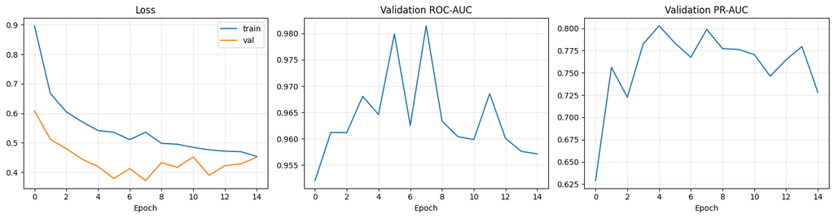

```python
# --- Plot training curves ---
fig, axes = plt.subplots(1, 3, figsize=(15, 4))
axes[0].plot(history['train_loss'], label='train'); axes[0].plot(history['val_loss'], label='val')
axes[0].set_title('Loss'); axes[0].set_xlabel('Epoch'); axes[0].legend(); axes[0].grid(alpha=0.3)
axes[1].plot(history['val_roc']); axes[1].set_title('Validation ROC-AUC'); axes[1].set_xlabel('Epoch'); axes[1].grid(alpha=0.3)
axes[2].plot(history['val_pr']);  axes[2].set_title('Validation PR-AUC');  axes[2].set_xlabel('Epoch'); axes[2].grid(alpha=0.3)
plt.tight_layout(); plt.show()
```

```
Heaviest-rain test day: predicting for 2024-01-11 (3-day rain ending day-prior: 63.6 mm)
```

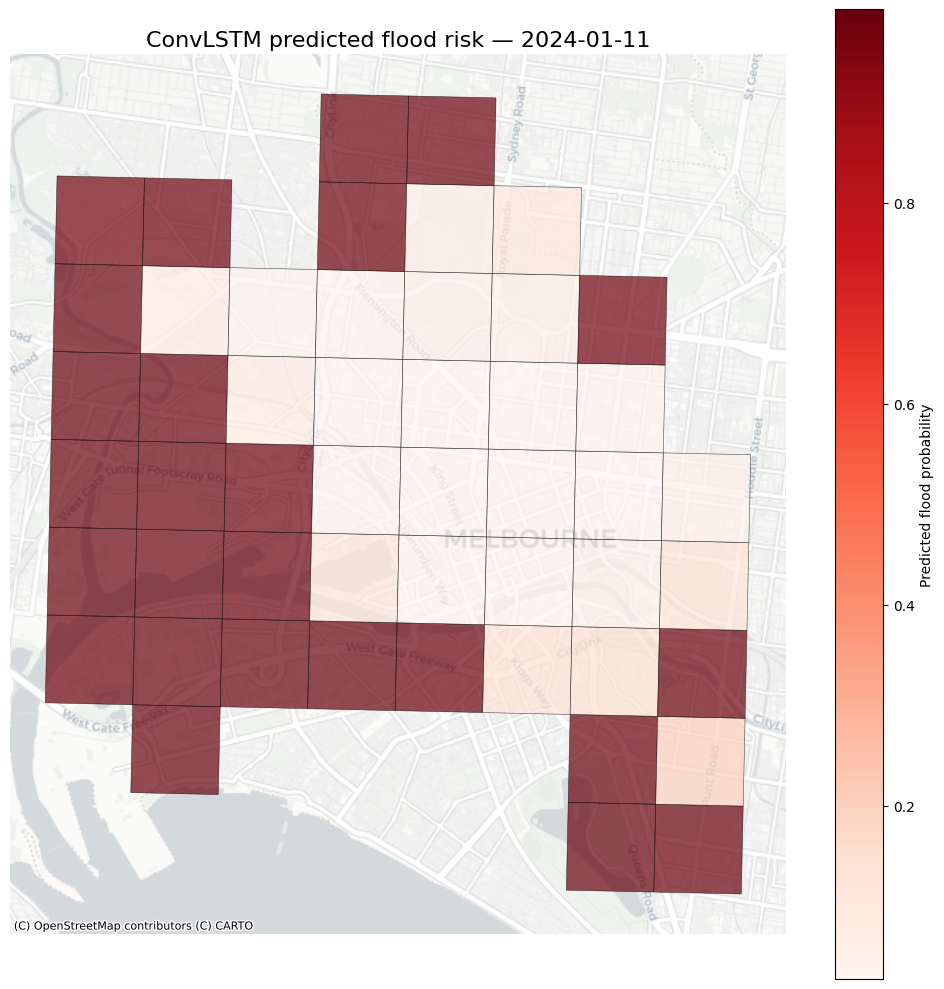

```python
# --- Predicted flood-risk map for the heaviest-rainfall day in the test set ---

# Find the day in the test set with the highest 3-day rainfall
test_dates = date_arr[test_idx]
test_rain_3d = rainfall_ts['rain_3d'].loc[test_dates].values
peak_offset = int(np.argmax(test_rain_3d))
peak_t_end  = test_idx[peak_offset]
# Need to confirm that this index has a valid window
if peak_t_end - WINDOW + 1 >= 0 and peak_t_end + 1 < n_days:
    target_day = date_arr[peak_t_end + 1]
    print(f'Heaviest-rain test day: predicting for {target_day.date()} (3-day rain ending day-prior: {test_rain_3d[peak_offset]:.1f} mm)')

    window = X_grid_z[peak_t_end - WINDOW + 1 : peak_t_end + 1]
    xb = torch.from_numpy(window[None]).to(device)
    model.eval()
    with torch.no_grad():
        prob_map = torch.sigmoid(model(xb)).cpu().numpy()[0]
    prob_map = prob_map * mask_grid  # zero invalid cells

    # Attach predicted probability back to grid geometries
    pred_per_cell = np.zeros(len(cell_index), dtype=np.float32)
    for r in range(n_rows):
        for c in range(n_cols):
            cp = grid_index_map[r, c]
            if cp >= 0:
                pred_per_cell[cp] = prob_map[r, c]

    grids_pred = grids.copy()
    grids_pred['flood_prob'] = [pred_per_cell[cell_index.index(cid)] for cid in grids_pred['id']]

    fig, ax = plt.subplots(figsize=(10, 10))
    grids_plot = grids_pred.to_crs(epsg=3857)
    grids_plot.plot(ax=ax, column='flood_prob', cmap='Reds', alpha=0.7,
                    edgecolor='black', linewidth=0.4, legend=True,
                    legend_kwds={'label': 'Predicted flood probability'})
    ctx.add_basemap(ax=ax, source=ctx.providers.CartoDB.Positron)
    ax.axis('off')
    ax.set_title(f'ConvLSTM predicted flood risk — {target_day.date()}', fontsize=16)
    plt.tight_layout(); plt.show()
else:
    print('Peak test day did not have a valid prediction window.')
```

## Section 9: Discussion, limitations and next steps

### What we built

A genuinely **spatiotemporal** machine learning pipeline that combines:

- Static spatial features (drainage, perviousness, trees, elevation) for every 1km² grid square of Melbourne CBD.
- Daily rainfall features — raw daily values plus 3-day, 7-day, and 30-day rolling statistics.
- Proxy flood-event labels built from a heavy-rain × vulnerability rule.
- Two models compared head-to-head: a logistic regression baseline and a ConvLSTM that learns from a sliding 7-day window of "Melbourne-as-an-image".

### Recommended next steps (in order of impact)

1. Replace proxy labels with **VicSES historical flood callouts** and **Melbourne Water flood records** geocoded onto the grid.
2. Ingest a **real DEM** and derive flow accumulation, slope, and topographic wetness index.
3. Use **radar-based rainfall grids** instead of a single gauge.
4. Expand the study area to **Greater Melbourne** and reduce cell size to 250 m or 100 m.
5. Try a **graph neural network** variant: nodes = cells, edges = drainage adjacency (downstream flow), which captures hydrological connectivity better than a regular grid.

## Section 10: Daily real-time flood risk prediction

A trained model is only useful if you can run it on fresh data. This section turns the trained ConvLSTM into a **real-time daily prediction pipeline** that produces an up-to-date flood-risk map for any day you choose.

### How it works

1. **Save the trained model and feature artifacts** to disk so they can be loaded later without retraining.
2. **Fetch the last 7 days of rainfall** from the BoM's public Daily Weather Observations service (Olympic Park station 086338).
3. **Build a 7-day input window** using exactly the same feature pipeline as during training — same standardisation stats, same column order, same calendar-month climatology.
4. **Run the model** to produce a flood probability for each grid cell.
5. **Render the prediction** as a coloured map of Melbourne.

### Caveats to be honest about

- **BoM Daily Weather Observations lag real-time by ~24 hours** — today's rainfall isn't published until tomorrow. So "today's prediction" really means "based on the last 7 days *ending yesterday*, predicting risk *for today*".
- The model was trained on **proxy labels** (Section 7). A high predicted probability means *"conditions resemble our heavy-rain + vulnerable-cell rule"*, **not** *"a flood is forecast"*.
- For genuine operational forecasting you'd plug in **BoM rainfall forecasts** (not just past observations) and validate predictions against real flood callouts.

```python
# --- Step 1: Save the trained model and feature artifacts ---
# Run this once after training completes; the resulting files are what the daily script loads.

import os, json, pickle

ARTIFACT_DIR = './flood_model_artifacts'
os.makedirs(ARTIFACT_DIR, exist_ok=True)

# 1a. Model weights
torch.save({
    'model_state_dict': model.state_dict(),
    'n_feats': n_feats,
    'hidden_ch': 16,
    'kernel_size': 3,
    'window': WINDOW,
}, f'{ARTIFACT_DIR}/convlstm.pt')

# 1b. Feature standardisation stats (mean/std from training)
np.savez(f'{ARTIFACT_DIR}/feature_stats.npz',
         train_mean=train_mean, train_std=train_std,
         feature_cols=np.array(feature_cols, dtype=object))

# 1c. Static spatial features per cell (these don't change over time)
static_feats.to_csv(f'{ARTIFACT_DIR}/static_features.csv', index=False)

# 1d. Grid geometry (for plotting)
grids.to_file(f'{ARTIFACT_DIR}/grids.geojson', driver='GeoJSON')

# 1e. Grid layout (row/col mapping)
np.savez(f'{ARTIFACT_DIR}/grid_layout.npz',
         grid_index_map=grid_index_map,
         valid_mask=valid_mask,
         cell_index=np.array(cell_index))

# 1f. Rainfall climatology — needed to compute the 30-day anomaly feature
# Store the monthly mean of 30-day rolling rainfall over the training period
month_30d_mean = (
    rainfall_ts.loc[rainfall_ts.index <= train_end_date]
    .assign(rain_30d=lambda d: d['rain_t'].rolling(30, min_periods=1).sum())
    .groupby(rainfall_ts.loc[rainfall_ts.index <= train_end_date].index.month)['rain_30d']
    .mean()
)
month_30d_mean.to_csv(f'{ARTIFACT_DIR}/month_30d_mean.csv')

print(f'Artifacts saved to {ARTIFACT_DIR}/')
print(os.listdir(ARTIFACT_DIR))
```

```
Artifacts saved to ./flood_model_artifacts/
['convlstm.pt', 'static_features.csv', 'grids.geojson', 'month_30d_mean.csv', 'grid_layout.npz', 'feature_stats.npz']
```

### Step 2: Fetch the last 7 days of rainfall from BoM

The Bureau of Meteorology publishes its Daily Weather Observations as monthly CSV files at a predictable URL. The function below:

1. Works out which months to download (a 7-day window can cross a month boundary, so we always fetch the current month plus the previous one).
2. Downloads each month's CSV.
3. Locates the header row (BoM CSVs have a variable number of preamble lines).
4. Extracts the date and rainfall columns.
5. Pads any missing days with 0 mm so the time series has no gaps.

We actually fetch **2 months** rather than just 7 days, because the `rain_30d_anom` feature needs ~30 days of recent history.

```python
def fetch_recent_rainfall(end_date=None, station_id='IDCJDW3033'):
    """Fetch ~60 days of rainfall ending at `end_date` (defaults to today).

    Returns a DataFrame indexed by date with a single 'rain_t' column.
    Olympic Park station 086338 -> file id IDCJDW3033.
    """
    import io
    import requests

    if end_date is None:
        end_date = pd.Timestamp.now().normalize()
    else:
        end_date = pd.Timestamp(end_date).normalize()

    headers = {
        'User-Agent': 'Mozilla/5.0 (compatible; FloodRiskResearch/1.0)',
        'Accept': 'text/csv,text/plain,*/*',
        'Referer': 'https://www.bom.gov.au/climate/dwo/IDCJDW3033.latest.shtml',
    }

    # We need current month + previous month to cover any 7-day window straddling month-end
    months_needed = []
    cursor = end_date
    for _ in range(2):
        months_needed.append((cursor.year, cursor.month))
        cursor = (cursor.replace(day=1) - pd.Timedelta(days=1)).replace(day=1)

    frames = []
    for yr, mo in months_needed:
        url = f'https://www.bom.gov.au/climate/dwo/{yr}{mo:02d}/text/{station_id}.{yr}{mo:02d}.csv'
        print(f'  fetching {url}')
        try:
            resp = requests.get(url, headers=headers, timeout=30)
            resp.raise_for_status()
            text = resp.text

            # Find the header row dynamically — BoM preamble length can vary
            lines = text.split('\n')
            header_idx = None
            for i, line in enumerate(lines):
                if '"Date"' in line or line.strip().startswith(',"Date"'):
                    header_idx = i
                    break
            if header_idx is None:
                raise ValueError(f'Could not locate header row in CSV for {yr}-{mo:02d}')

            df = pd.read_csv(io.StringIO(text), skiprows=header_idx)
            date_col = [c for c in df.columns if c.strip().lower() == 'date'][0]
            rain_col = [c for c in df.columns if 'rainfall' in c.strip().lower()][0]
            df = df[[date_col, rain_col]].rename(columns={date_col: 'date', rain_col: 'rain_t'})
            df['date'] = pd.to_datetime(df['date'], errors='coerce')
            df = df.dropna(subset=['date'])
            df['rain_t'] = pd.to_numeric(df['rain_t'], errors='coerce').fillna(0.0)
            frames.append(df)
        except Exception as e:
            print(f'    -> failed: {e}')

    if not frames:
        raise RuntimeError('No rainfall data could be fetched from BoM.')

    rain = pd.concat(frames, ignore_index=True).drop_duplicates('date').sort_values('date')
    rain = rain.set_index('date')
    # Pad any missing days with 0
    full = pd.date_range(rain.index.min(), end_date, freq='D')
    rain = rain.reindex(full).fillna(0.0)
    rain.index.name = 'date'
    return rain


# Try it
recent_rain = fetch_recent_rainfall()
print(f'\nRetrieved {len(recent_rain)} days, ending {recent_rain.index[-1].date()}')
print(f'Last 10 days:')
print(recent_rain.tail(10))
```

```
  fetching https://www.bom.gov.au/climate/dwo/202605/text/IDCJDW3033.202605.csv
  fetching https://www.bom.gov.au/climate/dwo/202604/text/IDCJDW3033.202604.csv

Retrieved 45 days, ending 2026-05-15
Last 10 days:
            rain_t
date
2026-05-06     0.0
2026-05-07    11.0
2026-05-08     2.8
2026-05-09     1.2
2026-05-10     0.6
2026-05-11     0.0
2026-05-12     0.2
2026-05-13     0.0
2026-05-14     0.2
2026-05-15     0.0
```

### Step 3: Build today's input window and run the model

This is the main inference function. It bundles everything together:

- Loads the saved model weights and feature statistics from disk.
- Fetches recent rainfall (using the function from Step 2).
- Computes the rolling-window rainfall features.
- Builds the 7-day × features × rows × columns input tensor — same shape the model saw during training.
- Standardises it using the **training-set mean and standard deviation** (so the model sees data on the same scale it learned on).
- Runs the model and produces a flood probability for every cell.
- Returns the predictions packaged into a GeoDataFrame ready for plotting.

The function returns three things: the geographic predictions, the target date, and a small summary dictionary (peak rainfall, number of high-risk cells, etc.) for the dashboard.

```python
def predict_for_date(target_date=None, artifact_dir=ARTIFACT_DIR):
    """Generate a flood-risk prediction for `target_date` (defaults to today).

    Returns: (GeoDataFrame with flood_prob column, target_date used)
    """
    if target_date is None:
        target_date = pd.Timestamp.now().normalize()
    else:
        target_date = pd.Timestamp(target_date).normalize()

    # Load artifacts
    ckpt = torch.load(f'{artifact_dir}/convlstm.pt', map_location=device, weights_only=False)
    stats = np.load(f'{artifact_dir}/feature_stats.npz', allow_pickle=True)
    static = pd.read_csv(f'{artifact_dir}/static_features.csv')
    grids_loaded = gpd.read_file(f'{artifact_dir}/grids.geojson')
    layout = np.load(f'{artifact_dir}/grid_layout.npz')
    month_clim = pd.read_csv(f'{artifact_dir}/month_30d_mean.csv', index_col=0).iloc[:, 0]

    train_mean = stats['train_mean']
    train_std  = stats['train_std']
    feature_cols_saved = list(stats['feature_cols'])
    grid_index_map = layout['grid_index_map']
    valid_mask = layout['valid_mask'].astype(bool)
    cell_index = list(layout['cell_index'])
    n_rows, n_cols = grid_index_map.shape
    WINDOW = ckpt['window']

    # Rebuild model
    model = FloodConvLSTM(in_ch=ckpt['n_feats'],
                          hidden_ch=ckpt['hidden_ch'],
                          kernel_size=ckpt['kernel_size']).to(device)
    model.load_state_dict(ckpt['model_state_dict'])
    model.eval()

    # Fetch rainfall: we need the 7 days ending yesterday (BoM publishes with ~1 day lag),
    # but also 30 days of context for the rain_30d_anom feature
    # window_end = target_date - 1 day (latest available observation)
    window_end = target_date - pd.Timedelta(days=1)
    rain = fetch_recent_rainfall(end_date=window_end)

    # Compute rolling features
    rain['rain_3d']  = rain['rain_t'].rolling(3,  min_periods=1).sum()
    rain['rain_7d']  = rain['rain_t'].rolling(7,  min_periods=1).sum()
    rain['rain_30d'] = rain['rain_t'].rolling(30, min_periods=1).sum()
    # Use saved climatology to compute anomaly consistently with training
    month_lookup = rain.index.month
    rain['rain_30d_anom'] = rain['rain_30d'].values - month_clim.loc[month_lookup].values
    rain = rain.drop(columns=['rain_30d'])

    # Take the 7 days ending on window_end
    window_dates = pd.date_range(window_end - pd.Timedelta(days=WINDOW-1), window_end, freq='D')
    rain_window = rain.loc[window_dates]
    if len(rain_window) != WINDOW:
        raise RuntimeError(f'Need {WINDOW} days of rainfall, got {len(rain_window)}')

    # Build (WINDOW, n_features, n_rows, n_cols) input
    static_cols = [c for c in feature_cols_saved if c not in ('rain_t', 'rain_3d', 'rain_7d', 'rain_30d_anom')]
    rain_cols   = ['rain_t', 'rain_3d', 'rain_7d', 'rain_30d_anom']

    n_feats = len(feature_cols_saved)
    X_input = np.zeros((WINDOW, n_feats, n_rows, n_cols), dtype=np.float32)

    for r in range(n_rows):
        for c in range(n_cols):
            cp = grid_index_map[r, c]
            if cp < 0:
                continue
            cell_id = cell_index[cp]
            cell_static = static[static['id'] == cell_id].iloc[0]
            for f_idx, fc in enumerate(feature_cols_saved):
                if fc in static_cols:
                    X_input[:, f_idx, r, c] = cell_static[fc]
                else:
                    X_input[:, f_idx, r, c] = rain_window[fc].values

    # Standardise using saved training stats
    X_input = (X_input - train_mean[0]) / train_std[0]
    X_input = X_input * valid_mask[None, None, :, :].astype(np.float32)

    # Run model
    xb = torch.from_numpy(X_input[None]).to(device)  # (1, WINDOW, C, H, W)
    with torch.no_grad():
        logits = model(xb)
        prob_map = torch.sigmoid(logits).cpu().numpy()[0]
    prob_map = prob_map * valid_mask.astype(np.float32)

    # Attach to geometries
    cell_probs = np.zeros(len(cell_index), dtype=np.float32)
    for r in range(n_rows):
        for c in range(n_cols):
            cp = grid_index_map[r, c]
            if cp >= 0:
                cell_probs[cp] = prob_map[r, c]

    grids_out = grids_loaded.copy()
    cell_id_to_prob = dict(zip(cell_index, cell_probs))
    grids_out['flood_prob'] = grids_out['id'].map(cell_id_to_prob).fillna(0.0)

    # Add summary metadata
    window_rain_total = rain_window['rain_t'].sum()
    window_3d_max     = rain_window['rain_3d'].max()

    return grids_out, target_date, {
        'window_dates': [d.date() for d in window_dates],
        'window_rain_total_mm': float(window_rain_total),
        'window_3d_max_mm': float(window_3d_max),
        'mean_predicted_prob': float(cell_probs[cell_probs > 0].mean()),
        'max_predicted_prob': float(cell_probs.max()),
        'high_risk_cells': int((cell_probs > 0.5).sum()),
    }


# Run it for today
grids_today, today, summary = predict_for_date()
print(f'\nPrediction for {today.date()}:')
for k, v in summary.items():
    print(f'  {k}: {v}')
```

```
  fetching https://www.bom.gov.au/climate/dwo/202605/text/IDCJDW3033.202605.csv
  fetching https://www.bom.gov.au/climate/dwo/202604/text/IDCJDW3033.202604.csv

Prediction for 2026-05-15:
  window_dates: [datetime.date(2026, 5, 8), datetime.date(2026, 5, 9), datetime.date(2026, 5, 10), datetime.date(2026, 5, 11), datetime.date(2026, 5, 12), datetime.date(2026, 5, 13), datetime.date(2026, 5, 14)]
  window_rain_total_mm: 5.0
  window_3d_max_mm: 15.0
  mean_predicted_prob: 0.045625053346157074
  max_predicted_prob: 0.14051757752895355
  high_risk_cells: 0
```

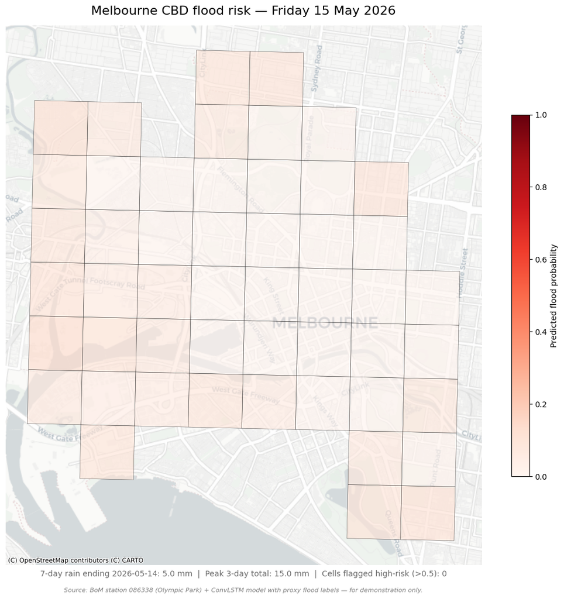

```
Map saved to flood_risk_2026-05-15.png
```

```python
# --- Step 4: Visualise today's flood risk ---

fig, ax = plt.subplots(figsize=(11, 11))
grids_plot = grids_today.to_crs(epsg=3857)

grids_plot.plot(
    ax=ax,
    column='flood_prob',
    cmap='Reds',
    alpha=0.65,
    edgecolor='black',
    linewidth=0.4,
    legend=True,
    vmin=0, vmax=1,
    legend_kwds={'label': 'Predicted flood probability', 'shrink': 0.6}
)
ctx.add_basemap(ax=ax, source=ctx.providers.CartoDB.Positron)
ax.axis('off')

title = f'Melbourne CBD flood risk — {today.strftime("%A %d %B %Y")}'
subtitle = (f'7-day rain ending {summary["window_dates"][-1]}: {summary["window_rain_total_mm"]:.1f} mm  '
            f'|  Peak 3-day total: {summary["window_3d_max_mm"]:.1f} mm  '
            f'|  Cells flagged high-risk (>0.5): {summary["high_risk_cells"]}')
ax.set_title(title, fontsize=16, pad=14)
ax.text(0.5, -0.02, subtitle, transform=ax.transAxes, ha='center', fontsize=10, color='dimgray')
ax.text(0.5, -0.05,
        'Source: BoM station 086338 (Olympic Park) + ConvLSTM model with proxy flood labels — for demonstration only.',
        transform=ax.transAxes, ha='center', fontsize=8, style='italic', color='gray')

plt.tight_layout()
plt.savefig(f'flood_risk_{today.date()}.png', dpi=150, bbox_inches='tight')
plt.show()
print(f'\nMap saved to flood_risk_{today.date()}.png')
```

```
  fetching https://www.bom.gov.au/climate/dwo/202605/text/IDCJDW3033.202605.csv
  fetching https://www.bom.gov.au/climate/dwo/202604/text/IDCJDW3033.202604.csv
```

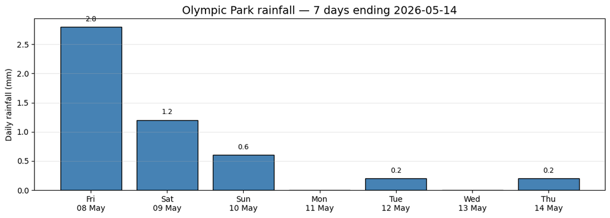

```python
# --- Step 5 (optional): Companion bar chart of the 7-day rainfall window ---

window_dates = summary['window_dates']
# Re-fetch the values from the rain dataframe (held in closure of predict_for_date — re-do for plotting)
rain_for_plot = fetch_recent_rainfall(end_date=today - pd.Timedelta(days=1))
plot_window = rain_for_plot.loc[pd.to_datetime(window_dates)]

fig, ax = plt.subplots(figsize=(11, 4))
bars = ax.bar([d.strftime('%a\n%d %b') for d in window_dates],
              plot_window['rain_t'].values,
              color='steelblue', edgecolor='black')
ax.set_ylabel('Daily rainfall (mm)')
ax.set_title(f'Olympic Park rainfall — 7 days ending {window_dates[-1]}', fontsize=14)
ax.grid(axis='y', alpha=0.3)
# Annotate each bar
for b, v in zip(bars, plot_window['rain_t'].values):
    if v > 0.1:
        ax.text(b.get_x() + b.get_width()/2, b.get_height() + 0.1, f'{v:.1f}', ha='center', fontsize=9)
plt.tight_layout()
plt.show()
```

### Running this for any other date

To generate a risk map for a different day, just pass `target_date` to `predict_for_date`:

```
grids_xmas, _, summary_xmas = predict_for_date(target_date='2025-12-25')
```

The function will fetch the BoM rainfall ending the day before the target date, build the 7-day window, and produce the same outputs.

### Limitations of this real-time pipeline

- One rainfall gauge for all of Melbourne CBD — same caveat as training.
- BoM DWO data has a ~24-hour publication lag.
- The model was trained on proxy labels, not real flood events. High predicted probability ≠ a flood will occur — it means *"conditions match our heavy-rain + vulnerable-cell rule"*.
- For actual operational use, you'd want BoM rainfall *forecasts* (not just observations) and validation against real flood callouts.

## Section 11: The interactive HTML dashboard

The final piece is a **self-contained HTML dashboard** that anyone can open in a web browser — no Python, no Jupyter, no installation required. This is the deliverable a city planner, council officer or emergency-services coordinator would actually look at.

### What the dashboard shows

- An **interactive zoomable map** of Melbourne where each 1km square is colour-coded by flood risk (red = high, amber = medium, green = low). Hover or tap on any square to see its exact predicted probability.
- **Headline numbers** at the top — the count of high-risk areas, total rainfall over the last 7 days, peak 3-day rainfall, and the highest predicted probability anywhere on the grid.
- A **7-day rainfall bar chart** showing how rain has fallen across the input window.
- A **plain-English summary** written for non-technical stakeholders.
- A footer with a clear disclaimer that this is a research tool, not an official warning, and links to the real flood-warning services.